# Question 1A: Areal Data (20 marks)

Shared with you are two files:

1. “burglary.Rdata” gives Burglary data for Sheffield: The variables are:
1. WARD_NO: ward number
2. WARD_NM: ward name
3. WARD_ID: census ID
4. HH: number of households
5. BURG: number of burglaries in 1995
6. TDI: Townsend deprivation index (TDI)
7. TO: population turnover (percentage residents having moved within one year of the 1991 census)
2. “wards_err.GAL” a GAL file to create Sheffield ward neighbours.

A ward is a local authority area, typically used for electoral purposes.

Material deprivation refers to the inability for individuals or households to afford those consumption goods and activities that are typical in a society at a given point in time, irrespective of people’s preferences with respect to these items. Material deprivation is measures using the Townsend Deprivation Index whereby a large positive implies deprived and a large negative implies affluent.

More info: https://en.wikipedia.org/wiki/Townsend_deprivation_index

```r
library(spdep)
```

Answer the following questions:

1. (5 marks) Load the GAL file and fix the error. Create a weights list object using the (i) row normalised weights style and (ii) binary weights style.

Running (wards.nb = read.gal(“wards_err.GAL”)) throws the following error:

`Error in read.gal("wards_err.GAL") : GAL file corrupted at region 10`

To fix this, we simply examine the GAL file in .txt format, i.e.,

```r
# 0 29 sheffield wards
# 1 5
# 10 19 14 22 9
# 2 3
# 13 16 18
# 3 5
# 27 20 8 11 5
# 4 5
# 21 12 25 10 19
# 5 6
# 3 23 8 11 21 6
# 6 6
# 8 5 21 17 25 24
# 7 1
# 27
# 8 6
# 3 5 6 17 13 16
# 9 4             # the next line should have 4 region IDs
# 12 10 1 22
###############
# 10 4        #   # the next line should have 5 (and not 4) region IDs
# 12 4 19 1 9 #
###############
# 11 5            # the next line should have 5 region IDs
# 20 3 26 23 5
# 12 6
# 27 29 21 4 10 9
# 13 4
# 8 16 18 2
# 14 6
# 25 24 16 19 1 22
# 15 3
# 27 23 29
# 16 7
# 8 17 24 13 14 2 22
# 17 4
# 8 6 24 16
# 18 2
# 13 2
# 19 5
# 4 25 10 14 1
# 20 4
# 27 3 26 11
# 21 7
# 23 5 29 6 12 4 25
# 22 4
# 16 14 1 9
# 23 7
# 27 26 11 15 5 29 21
# 24 5
# 6 17 25 16 14
# 25 6
# 21 6 4 24 19 14
# 26 4
# 27 20 23 11
# 27 9
# 28 7 20 3 26 23 15 29 12
# 28 1
# 27
# 29 5
# 27 23 15 21 12
```

Replacing 4 with 5 to the right of 10 in the enclosed box above resolves the error. We then save the updated GAL file as `wards.GAL` and continue as follows:

```r
(wards.nb = read.gal("wards.GAL"))
```

```
## Neighbour list object:
## Number of regions: 29
## Number of nonzero links: 140
## Percentage nonzero weights: 16.64685
## Average number of links: 4.827586
```

```r
(wards.wlist = nb2listw(wards.nb))              # (i)
```

```
## Characteristics of weights list object:
## Neighbour list object:
## Number of regions: 29
## Number of nonzero links: 140
## Percentage nonzero weights: 16.64685
## Average number of links: 4.827586
##
## Weights style: W
## Weights constants summary:
##    n  nn S0       S1       S2
## W 29 841 29 13.60415 125.6183
```

```r
(wards.wlistB = nb2listw(wards.nb, style="B"))  # (ii)
```

```
## Characteristics of weights list object:
## Neighbour list object:
## Number of regions: 29
## Number of nonzero links: 140
## Percentage nonzero weights: 16.64685
## Average number of links: 4.827586
##
## Weights style: B
## Weights constants summary:
##    n  nn  S0  S1   S2
## B 29 841 140 280 3056
```

2. (10 marks) Load the burglary dataset and create a new variable (give a summary): number of burglaries per 1000 households.

```r
# Sheffield burglary data
load("burglary.Rdata")
head(burglary)
```

```
##   WARD_NO    WARD_NM WARD_ID   HH BURG   TDI    TO
## 1       1  Beauchief  05CGFA 8575  267 -4.93  6.71
## 2       2     Birley  05CGFB 7856  156 -0.04  6.14
## 3       3 Brightside  05CGFC 6565  476  1.18  9.84
## 4       4  Broomhill  05CGFD 5601  436 -3.18 20.60
## 5       5 Burngreave  05CGFE 6253  837  3.90 11.42
## 6       6     Castle  05CGFF 5998  336  6.06 14.61
```

```r
burglary$BURG_1000 = (burglary$BURG/burglary$HH)*1000
head(burglary)
```

```
##   WARD_NO    WARD_NM WARD_ID   HH BURG   TDI    TO BURG_1000
## 1       1  Beauchief  05CGFA 8575  267 -4.93  6.71  31.13703
## 2       2     Birley  05CGFB 7856  156 -0.04  6.14  19.85743
## 3       3 Brightside  05CGFC 6565  476  1.18  9.84  72.50571
## 4       4  Broomhill  05CGFD 5601  436 -3.18 20.60  77.84324
## 5       5 Burngreave  05CGFE 6253  837  3.90 11.42 133.85575
## 6       6     Castle  05CGFF 5998  336  6.06 14.61  56.01867
```

1. Conduct a Moran’s test on this variable and comment on the results.

```r
# Moran's I
moran.test(burglary$BURG_1000, listw=wards.wlist)
```

```
##
##  Moran I test under randomisation
##
## data:  burglary$BURG_1000
## weights: wards.wlist
##
## Moran I statistic standard deviate = 3.854, p-value = 5.81e-05
## alternative hypothesis: greater
## sample estimates:
## Moran I statistic       Expectation          Variance
##        0.40504628       -0.03571429        0.01307930
```

2. What is the null hypothesis of the above test. Show the calculation to get the null Moran’s statistic.

```r
# Reject H0 at 5% level of significance, reject the null of no spatial autocorrelation.
# There is sufficient evidence to suggest a significant spatial autocorrealtion for burglaries per 1000 HH.

-1/(nrow(burglary)-1) # H0
```

```
## [1] -0.03571429
```

3. Generate local Moran’s I statistics for each ward and show the calculation of the global Moran’s I statistic as the sum of local Moran’s I statistics.

```r
localm = localmoran(burglary$BURG_1000, listw=wards.wlist)
head(localm)
```

```
##          Ii          E.Ii      Var.Ii     Z.Ii Pr(z != E(Ii))
## 1 0.1339575 -0.0190325065 0.092244965 0.503723      0.6144560
## 2 0.8621616 -0.0445835934 0.381259568 1.468503      0.1419676
## 3 0.4327158 -0.0170226182 0.082672667 1.564152      0.1177818
## 4 0.3620037 -0.0272594639 0.131010586 1.075450      0.2821735
## 5 1.1265478 -0.2793681812 0.792859143 1.578924      0.1143534
## 6 0.1307923 -0.0005518392 0.002172094 2.818198      0.0048294
```

```r
sum(localm[,1])/nrow(burglary) # Global Moran's I as the sum of Local Moran's
```

```
## [1] 0.4050463
```

4. How many spatial outliers are there for the variable burglaries per 1000 households?

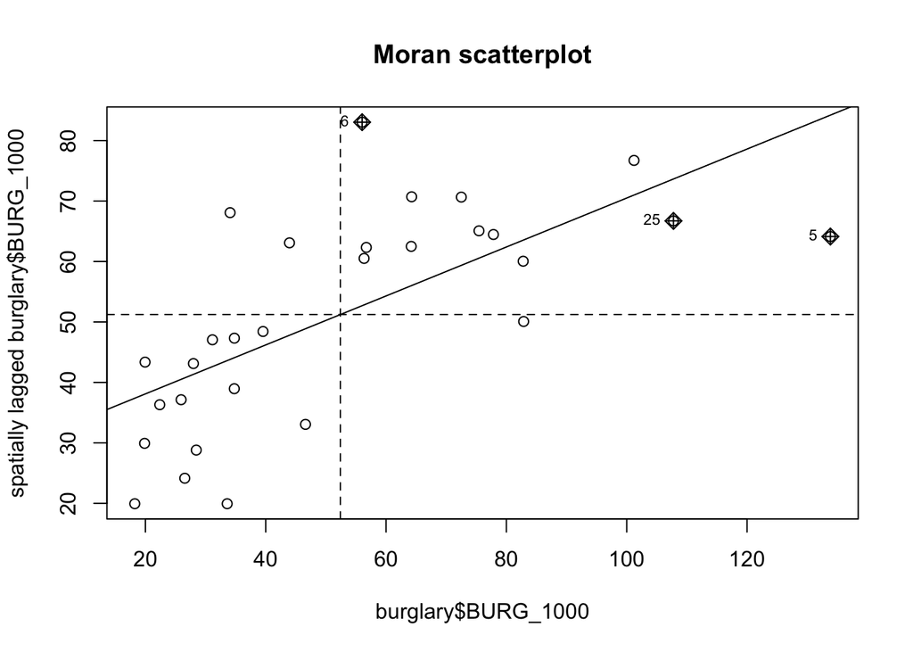

```r
moran.plot(burglary$BURG_1000, wards.wlist, main="Moran scatterplot") # Moran plot
```

```r
# There are 3 spatial outliers.
```

3. (5 marks) Create a binary variable based on TDI where positive means deprived (False), and negative means not deprived (True). Give a table for the new variable. Conduct a join count analysis on this new variable. State your conclusions clearly.

```r
burglary$TDI_IO = as.factor(burglary$TDI < 0)
head(burglary)
```

```
##   WARD_NO    WARD_NM WARD_ID   HH BURG   TDI    TO BURG_1000 TDI_IO
## 1       1  Beauchief  05CGFA 8575  267 -4.93  6.71  31.13703   TRUE
## 2       2     Birley  05CGFB 7856  156 -0.04  6.14  19.85743   TRUE
## 3       3 Brightside  05CGFC 6565  476  1.18  9.84  72.50571  FALSE
## 4       4  Broomhill  05CGFD 5601  436 -3.18 20.60  77.84324   TRUE
## 5       5 Burngreave  05CGFE 6253  837  3.90 11.42 133.85575  FALSE
## 6       6     Castle  05CGFF 5998  336  6.06 14.61  56.01867  FALSE
```

```r
table(burglary$TDI_IO)
```

```
##
## FALSE  TRUE
##    13    16
```

```r
# Join Count
joincount.multi(burglary$TDI_IO, listw=wards.wlistB)
```

```
##             Joincount Expected Variance z-value
## FALSE:FALSE   24.0000  13.4483   8.0503  3.7189
## TRUE:TRUE     25.0000  20.6897  10.5589  1.3265
## TRUE:FALSE    21.0000  35.8621  14.6411 -3.8841
## Jtot          21.0000  35.8621  14.6411 -3.8841
```

```r
# The observed BW count (T:F = 21) is less than the expected value under CSR (T:F = 35.9).
# Sufficient evidence to suggest significant clustering at 5% level of significance.
```

### EXTRA: Spatial Regression

```r
library(spatialreg)

# OLS fit
ols = lm(BURG_1000 ~ TDI + TO, data = burglary)
summary(ols)
```

```
##
## Call:
## lm(formula = BURG_1000 ~ TDI + TO, data = burglary)
##
## Residuals:
##     Min      1Q  Median      3Q     Max
## -33.086 -12.140  -3.025   6.774  63.845
##
## Coefficients:
##             Estimate Std. Error t value Pr(>|t|)
## (Intercept)   14.365     11.251   1.277  0.21294
## TDI            3.316      1.029   3.221  0.00342 **
## TO             3.740      1.034   3.618  0.00126 **
## ---
## Signif. codes:  0 '***' 0.001 '**' 0.01 '*' 0.05 '.' 0.1 ' ' 1
##
## Residual standard error: 19.97 on 26 degrees of freedom
## Multiple R-squared:  0.5783, Adjusted R-squared:  0.5459
## F-statistic: 17.83 on 2 and 26 DF,  p-value: 1.332e-05
```

```r
lmtest::bptest(ols)
```

```
##
##  studentized Breusch-Pagan test
##
## data:  ols
## BP = 3.1361, df = 2, p-value = 0.2084
```

```r
tseries::jarque.bera.test(ols$residuals)
```

```
##
##  Jarque Bera Test
##
## data:  ols$residuals
## X-squared = 17.306, df = 2, p-value = 0.0001746
```

```r
# spatial test
lm.morantest(ols, wards.wlist)
```

```
##
##  Global Moran I for regression residuals
##
## data:
## model: lm(formula = BURG_1000 ~ TDI + TO, data = burglary)
## weights: wards.wlist
##
## Moran I statistic standard deviate = 1.6754, p-value = 0.04693
## alternative hypothesis: greater
## sample estimates:
## Observed Moran I      Expectation         Variance
##       0.10638930      -0.07889503       0.01223094
```

```r
moran.test(burglary$BURG_1000, wards.wlist)
```

```
##
##  Moran I test under randomisation
##
## data:  burglary$BURG_1000
## weights: wards.wlist
##
## Moran I statistic standard deviate = 3.854, p-value = 5.81e-05
## alternative hypothesis: greater
## sample estimates:
## Moran I statistic       Expectation          Variance
##        0.40504628       -0.03571429        0.01307930
```

```r
# spatial models
sar = spautolm(BURG_1000 ~ 1, data=burglary, wards.wlist)
slm = lagsarlm(BURG_1000 ~ TDI + TO, data=burglary, wards.wlist)
sem = errorsarlm(BURG_1000 ~ TDI + TO, data=burglary, wards.wlist)
sarar = sacsarlm(BURG_1000 ~ TDI + TO, data=burglary, wards.wlist)

summary(sar)
```

```
##
## Call: spautolm(formula = BURG_1000 ~ 1, data = burglary, listw = wards.wlist)
##
## Residuals:
##      Min       1Q   Median       3Q      Max
## -30.1756 -16.7919  -6.8173   6.9833  72.3858
##
## Coefficients:
##             Estimate Std. Error z value  Pr(>|z|)
## (Intercept)   55.166     14.191  3.8874 0.0001013
##
## Lambda: 0.70327 LR test value: 10.553 p-value: 0.0011597
## Numerical Hessian standard error of lambda: 0.16227
##
## Log likelihood: -133.6486
## ML residual variance (sigma squared): 514.21, (sigma: 22.676)
## Number of observations: 29
## Number of parameters estimated: 3
## AIC: 273.3
```

```r
summary(slm)
```

```
##
## Call:
## lagsarlm(formula = BURG_1000 ~ TDI + TO, data = burglary, listw = wards.wlist)
##
## Residuals:
##      Min       1Q   Median       3Q      Max
## -36.9135  -9.6964  -1.6885   4.1457  62.8032
##
## Type: lag
## Coefficients: (asymptotic standard errors)
##             Estimate Std. Error z value Pr(>|z|)
## (Intercept)  4.29345   12.17009  0.3528 0.724248
## TDI          2.71299    0.99178  2.7355 0.006229
## TO           3.08345    1.00869  3.0569 0.002236
##
## Rho: 0.32692, LR test value: 2.1178, p-value: 0.14559
## Asymptotic standard error: 0.20243
##     z-value: 1.615, p-value: 0.10631
## Wald statistic: 2.6082, p-value: 0.10631
##
## Log likelihood: -125.3448 for lag model
## ML residual variance (sigma squared): 324.74, (sigma: 18.02)
## Number of observations: 29
## Number of parameters estimated: 5
## AIC: 260.69, (AIC for lm: 260.81)
## LM test for residual autocorrelation
## test value: 0.071058, p-value: 0.7898
```

```r
summary(sem)
```

```
##
## Call:
## errorsarlm(formula = BURG_1000 ~ TDI + TO, data = burglary, listw = wards.wlist)
##
## Residuals:
##      Min       1Q   Median       3Q      Max
## -33.4289 -11.1386  -4.2237   5.7013  65.2579
##
## Type: error
## Coefficients: (asymptotic standard errors)
##             Estimate Std. Error z value Pr(>|z|)
## (Intercept)  15.8794    12.3080  1.2902 0.196992
## TDI           3.1722     1.1153  2.8444 0.004450
## TO            3.5959     1.1058  3.2519 0.001146
##
## Lambda: 0.27258, LR test value: 0.87015, p-value: 0.35091
## Asymptotic standard error: 0.23958
##     z-value: 1.1377, p-value: 0.25524
## Wald statistic: 1.2944, p-value: 0.25524
##
## Log likelihood: -125.9687 for error model
## ML residual variance (sigma squared): 341.57, (sigma: 18.482)
## Number of observations: 29
## Number of parameters estimated: 5
## AIC: 261.94, (AIC for lm: 260.81)
```

```r
summary(sarar)
```

```
##
## Call:
## sacsarlm(formula = BURG_1000 ~ TDI + TO, data = burglary, listw = wards.wlist)
##
## Residuals:
##       Min        1Q    Median        3Q       Max
## -36.94614  -9.02681  -0.95429   4.34861  61.85049
##
## Type: sac
## Coefficients: (asymptotic standard errors)
##             Estimate Std. Error z value Pr(>|z|)
## (Intercept)   2.2932    15.8659  0.1445  0.88508
## TDI           2.6199     1.1196  2.3400  0.01928
## TO            2.9935     1.1660  2.5674  0.01025
##
## Rho: 0.38161
## Asymptotic standard error: 0.38832
##     z-value: 0.9827, p-value: 0.32575
## Lambda: -0.10567
## Asymptotic standard error: 0.55148
##     z-value: -0.19162, p-value: 0.84804
##
## LR test value: 2.1692, p-value: 0.33804
##
## Log likelihood: -125.3191 for sac model
## ML residual variance (sigma squared): 320.46, (sigma: 17.901)
## Number of observations: 29
## Number of parameters estimated: 6
## AIC: 262.64, (AIC for lm: 260.81)
```

```r
# LM tests
lm.LMtests(ols, listw=wards.wlist, test="all")
```

```
## Please update scripts to use lm.RStests in place of lm.LMtests
```

```
##
##  Rao's score (a.k.a Lagrange multiplier) diagnostics for spatial
##  dependence
##
## data:
## model: lm(formula = BURG_1000 ~ TDI + TO, data = burglary)
## test weights: listw
##
## RSerr = 0.69971, df = 1, p-value = 0.4029
##
##
##  Rao's score (a.k.a Lagrange multiplier) diagnostics for spatial
##  dependence
##
## data:
## model: lm(formula = BURG_1000 ~ TDI + TO, data = burglary)
## test weights: listw
##
## RSlag = 1.9675, df = 1, p-value = 0.1607
##
##
##  Rao's score (a.k.a Lagrange multiplier) diagnostics for spatial
##  dependence
##
## data:
## model: lm(formula = BURG_1000 ~ TDI + TO, data = burglary)
## test weights: listw
##
## adjRSerr = 0.40697, df = 1, p-value = 0.5235
##
##
##  Rao's score (a.k.a Lagrange multiplier) diagnostics for spatial
##  dependence
##
## data:
## model: lm(formula = BURG_1000 ~ TDI + TO, data = burglary)
## test weights: listw
##
## adjRSlag = 1.6747, df = 1, p-value = 0.1956
##
##
##  Rao's score (a.k.a Lagrange multiplier) diagnostics for spatial
##  dependence
##
## data:
## model: lm(formula = BURG_1000 ~ TDI + TO, data = burglary)
## test weights: listw
##
## SARMA = 2.3744, df = 2, p-value = 0.3051
```

```r
# LR tests (H0: OLS linear model)
LR1.Sarlm(slm) # do not reject H0
```

```
##
##  Likelihood Ratio diagnostics for spatial dependence
##
## data:
## Likelihood ratio = 2.1178, df = 1, p-value = 0.1456
## sample estimates:
## Log likelihood of spatial lag model         Log likelihood of OLS fit y
##                           -125.3448                           -126.4037
```

```r
LR1.Sarlm(sarar) # do not reject H0
```

```
##
##  Likelihood Ratio diagnostics for spatial dependence
##
## data:
## Likelihood ratio = 2.1692, df = 2, p-value = 0.338
## sample estimates:
## Log likelihood of spatial lag model         Log likelihood of OLS fit y
##                           -125.3191                           -126.4037
```

```r
# comprehensive LR tests
LR.Sarlm(sem,sarar) # SEM vs SARAR --> do not reject H0
```

```
##
##  Likelihood ratio for spatial linear models
##
## data:
## Likelihood ratio = -1.299, df = 1, p-value = 0.2544
## sample estimates:
##   Log likelihood of sem Log likelihood of sarar
##               -125.9687               -125.3191
```

```r
LR.Sarlm(slm,sarar) # SLM vs SARAR --> do not reject H0
```

```
##
##  Likelihood ratio for spatial linear models
##
## data:
## Likelihood ratio = -0.051335, df = 1, p-value = 0.8208
## sample estimates:
##   Log likelihood of slm Log likelihood of sarar
##               -125.3448               -125.3191
```

```r
LR.Sarlm(sar,slm) # SAR vs SLM --> reject H0
```

```
##
##  Likelihood ratio for spatial linear models
##
## data:
## Likelihood ratio = -16.608, df = 2, p-value = 0.0002476
## sample estimates:
## Log likelihood of sar Log likelihood of slm
##             -133.6486             -125.3448
```

```r
# Conclusion: based on the LR tests, the OLS model seems to be the most suitable model.
```